# Tugas 2 Praktikum MPDW

Sofia Lorena

2025-08-31

```r
library(readxl)
library("forecast")
```

```r
library("graphics")
library("TTR")
library("TSA")
```

# Import Data

```r
# Import Data
data <- read_excel("C:\\Users\\LENOVO\\Downloads\\coffe_prices_kelompok.xlsx")
data
```

```
## # A tibble: 500 × 3
##     ...1 `Date (Monthly)`    `Coffee Arabica ($/kg)`
##    <dbl> <dttm>                                <dbl>
##  1     1 1960-01-01 00:00:00                   0.941
##  2     2 1960-02-01 00:00:00                   0.947
##  3     3 1960-03-01 00:00:00                   0.928
##  4     4 1960-04-01 00:00:00                   0.930
##  5     5 1960-05-01 00:00:00                   0.92
##  6     6 1960-06-01 00:00:00                   0.912
##  7     7 1960-07-01 00:00:00                   0.916
##  8     8 1960-08-01 00:00:00                   0.929
##  9     9 1960-09-01 00:00:00                   0.923
## 10    10 1960-10-01 00:00:00                   0.924
## # ℹ 490 more rows
```

```r
data100 <- head(data, 100)
data100
```

```
## # A tibble: 100 × 3
##     ...1 `Date (Monthly)`    `Coffee Arabica ($/kg)`
##    <dbl> <dttm>                                <dbl>
##  1     1 1960-01-01 00:00:00                   0.941
##  2     2 1960-02-01 00:00:00                   0.947
##  3     3 1960-03-01 00:00:00                   0.928
##  4     4 1960-04-01 00:00:00                   0.930
##  5     5 1960-05-01 00:00:00                   0.92
##  6     6 1960-06-01 00:00:00                   0.912
##  7     7 1960-07-01 00:00:00                   0.916
##  8     8 1960-08-01 00:00:00                   0.929
##  9     9 1960-09-01 00:00:00                   0.923
## 10    10 1960-10-01 00:00:00                   0.924
## # ℹ 90 more rows
```

# Eksplorasi Data

```r
View(data100)
str(data100)
```

```
## tibble [100 × 3] (S3: tbl_df/tbl/data.frame)
##  $ ...1                 : num [1:100] 1 2 3 4 5 6 7 8 9 10 ...
##  $ Date (Monthly)       : POSIXct[1:100], format: "1960-01-01" "1960-02-01" ...
##  $ Coffee Arabica ($/kg): num [1:100] 0.941 0.947 0.928 0.93 0.92 ...
```

```r
dim(data100)
```

```
## [1] 100   3
```

```r
data100.ts <- ts(data100$`Coffee Arabica ($/kg)`)
data100.ts
```

```
## Time Series:
## Start = 1
## End = 100
## Frequency = 1
##   [1] 0.9409 0.9469 0.9281 0.9303 0.9200 0.9123 0.9160 0.9292 0.9226 0.9237
##  [11] 0.9116 0.9006 0.9145 0.9167 0.9105 0.9017 0.8929 0.8891 0.8929 0.8935
##  [21] 0.8891 0.8852 0.8830 0.8774 0.8774 0.8770 0.8609 0.8466 0.8256 0.8047
##  [31] 0.8131 0.8190 0.8256 0.8109 0.8124 0.8179 0.8267 0.8031 0.8109 0.8080
##  [41] 0.7970 0.7992 0.8064 0.8047 0.8020 0.8042 0.8069 0.7998 0.9259 0.9414
##  [51] 1.0351 1.0042 1.0203 1.0053 1.0214 1.0490 1.0373 1.0379 1.0340 1.0053
##  [61] 1.0119 1.0384 0.9899 0.9744 0.9612 0.9811 0.9811 1.0009 0.9987 1.0097
##  [71] 1.0251 1.0318 1.0119 0.9722 0.9546 0.9546 0.9458 0.9237 0.9171 0.9171
##  [81] 0.8995 0.8885 0.8869 0.8728 0.8501 0.8441 0.8228 0.8508 0.8891 0.9092
##  [91] 0.9026 0.8761 0.8607 0.8472 0.8666 0.8512 0.8660 0.8691 0.8821 0.8860
```

```r
summary(data100.ts)
```

```
##    Min. 1st Qu.  Median    Mean 3rd Qu.    Max.
##  0.7970  0.8506  0.9001  0.9063  0.9546  1.0490
```

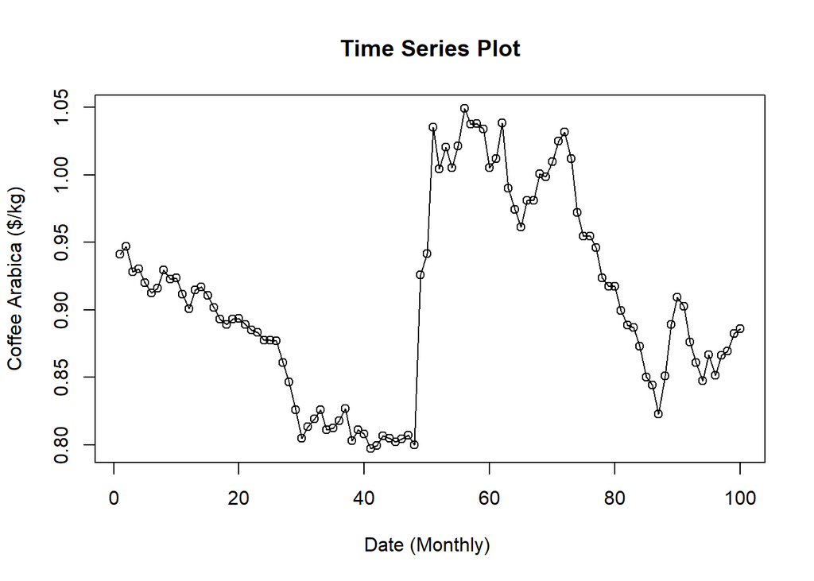

```r
ts.plot(data100.ts, xlab="Date (Monthly) ", ylab="Coffee Arabica ($/kg)",
        main = "Time Series Plot")
points(data100.ts)
```

# Pemulusan

## Single Moving Average (AMA) dan Double Moving Average (DMA)

```r
n <- nrow(data100)
n_train <- floor(0.8 * n)

# SMA/DMA
training_ma <- data100[1:n_train, ]
testing_ma  <- data100[(n_train+1):n, ]
train_ma.ts <- ts(training_ma$`Coffee Arabica ($/kg)`)
test_ma.ts  <- ts(testing_ma$`Coffee Arabica ($/kg)`)

# SES/DES
training <- data100[1:n_train, ]
testing  <- data100[(n_train+1):n, ]
train.ts <- ts(training$`Coffee Arabica ($/kg)`)
test.ts  <- ts(testing$`Coffee Arabica ($/kg)`)
```

```r
# Jumlah observasi
n <- nrow(data100)

# Batas 80% data latih
n_train <- floor(0.8 * n)

# Bagi data untuk SMA/DMA
training_ma <- data100[1:n_train, ]
testing_ma  <- data100[(n_train+1):n, ]

# Ubah ke time series
train_ma.ts <- ts(training_ma$`Coffee Arabica ($/kg)`)
test_ma.ts  <- ts(testing_ma$`Coffee Arabica ($/kg)`)
```

### Pembagian Data

Pembagian data latih dan data uji dilakukan dengan perbandingan 80% data latih dan 20% data uji.

```r
# hitung jumlah data
n <- nrow(data100)

# tentukan batas 80%
n_train <- floor(0.8 * n)

# bagi data
training_ma <- data100[1:n_train, ]
testing_ma  <- data100[(n_train+1):n, ]

# ubah ke time series
train_ma.ts <- ts(training_ma$`Coffee Arabica ($/kg)`)
test_ma.ts  <- ts(testing_ma$`Coffee Arabica ($/kg)`)
```

### Eksplorasi Data

Eksplorasi data dilakukan pada keseluruhan data, data latih serta data uji menggunakan plot data deret waktu.

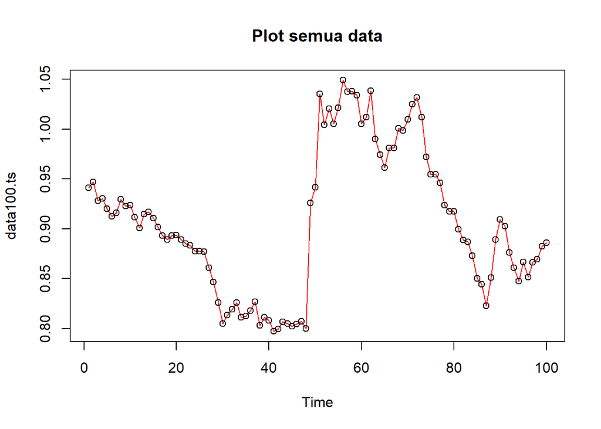

```r
#eksplorasi keseluruhan data
plot(data100.ts, col="red",main="Plot semua data")
points(data100.ts)
```

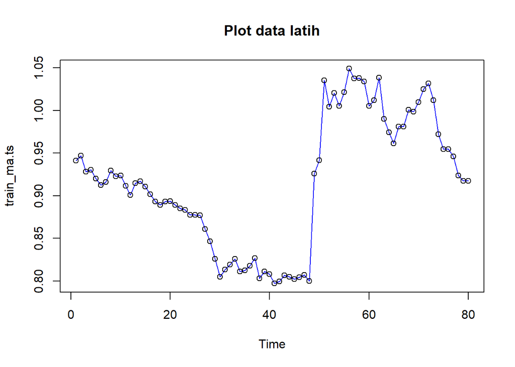

```r
#eksplorasi data latih
plot(train_ma.ts, col="blue",main="Plot data latih")
points(train_ma.ts)
```

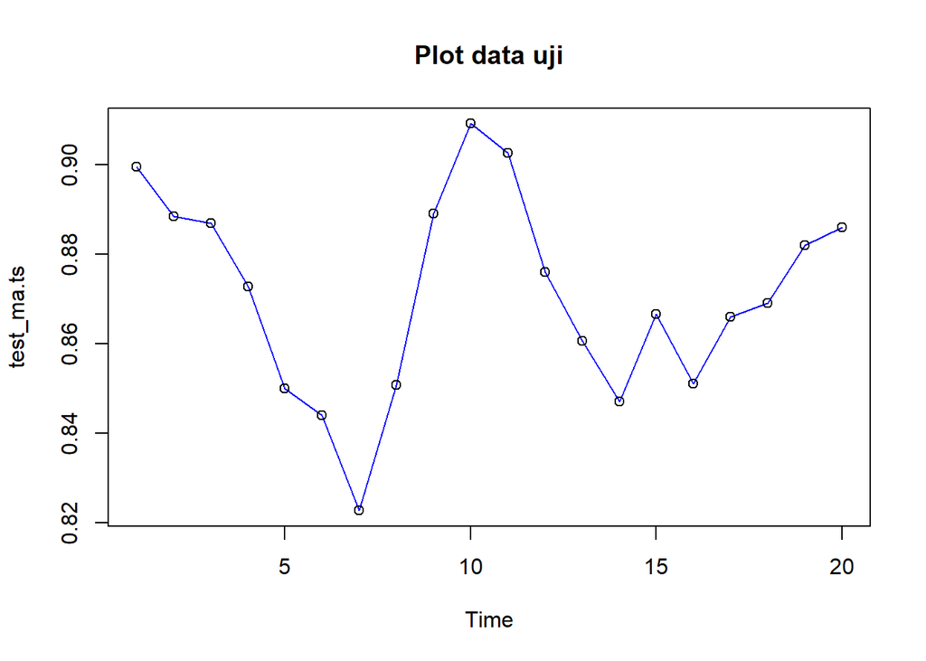

```r
#eksplorasi data uji
plot(test_ma.ts, col="blue",main="Plot data uji")
points(test_ma.ts)
```

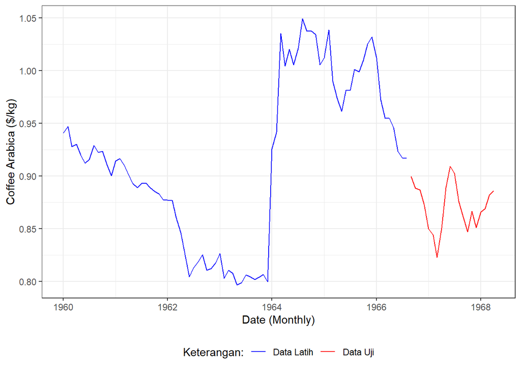

```r
library(ggplot2)
ggplot() +
  geom_line(data = training_ma, aes(x = `Date (Monthly)`, y = `Coffee Arabica ($/kg)`, col = "Data Latih")) +
  geom_line(data = testing_ma, aes(x = `Date (Monthly)`, y = `Coffee Arabica ($/kg)`, col = "Data Uji")) +
  labs(x = "Date (Monthly)", y = "Coffee Arabica ($/kg)", color = "Legend") +
   scale_colour_manual(name="Keterangan:", breaks = c("Data Latih", "Data Uji"),
                      values = c("blue", "red")) +
  theme_bw() + theme(legend.position = "bottom",
                     plot.caption = element_text(hjust=0.5, size=12))
```

### Single Moving Average

```r
# Pemulusan SMA dengan m = 4
data.sma <- SMA(train_ma.ts, n = 4)
data.sma
```

```
## Time Series:
## Start = 1
## End = 80
## Frequency = 1
##  [1]       NA       NA       NA 0.936550 0.931325 0.922675 0.919650 0.919375
##  [9] 0.920025 0.922875 0.921775 0.914625 0.912600 0.910850 0.910575 0.910850
## [17] 0.905450 0.898550 0.894150 0.892100 0.891150 0.890175 0.887700 0.883675
## [25] 0.880750 0.878700 0.873175 0.865475 0.852525 0.834450 0.822500 0.815600
## [33] 0.815600 0.817150 0.816975 0.816700 0.816975 0.815025 0.814650 0.812175
## [41] 0.804750 0.803775 0.802650 0.801825 0.803075 0.804325 0.804450 0.803225
## [49] 0.834200 0.868500 0.925550 0.976650 1.000250 1.016225 1.012800 1.024000
## [57] 1.028250 1.036400 1.039550 1.028625 1.022275 1.022400 1.011375 1.003650
## [65] 0.990975 0.976650 0.974450 0.981075 0.990450 0.997600 1.008600 1.016325
## [73] 1.019625 1.010250 0.992625 0.973325 0.956800 0.944675 0.935300 0.925925
```

```r
# Ramalan 1 periode ke depan
data.ramal <- c(NA, data.sma)

# Gabungkan ke dalam tabel
data.gab <- cbind(
  aktual    = c(train_ma.ts),
  pemulusan = c(data.sma, rep(NA, length(test_ma.ts))),
  ramalan   = c(data.ramal, rep(data.ramal[length(data.ramal)], length(test_ma.ts) - 1))
)
data.gab  # hasil pemulusan dan ramalan
```

```
##        aktual pemulusan  ramalan
##   [1,] 0.9409        NA       NA
##   [2,] 0.9469        NA       NA
##   [3,] 0.9281        NA       NA
##   [4,] 0.9303  0.936550       NA
##   [5,] 0.9200  0.931325 0.936550
##   [6,] 0.9123  0.922675 0.931325
##   [7,] 0.9160  0.919650 0.922675
##   [8,] 0.9292  0.919375 0.919650
##   [9,] 0.9226  0.920025 0.919375
##  [10,] 0.9237  0.922875 0.920025
##  [11,] 0.9116  0.921775 0.922875
##  [12,] 0.9006  0.914625 0.921775
##  [13,] 0.9145  0.912600 0.914625
##  [14,] 0.9167  0.910850 0.912600
```

[output cut: 86 more lines]

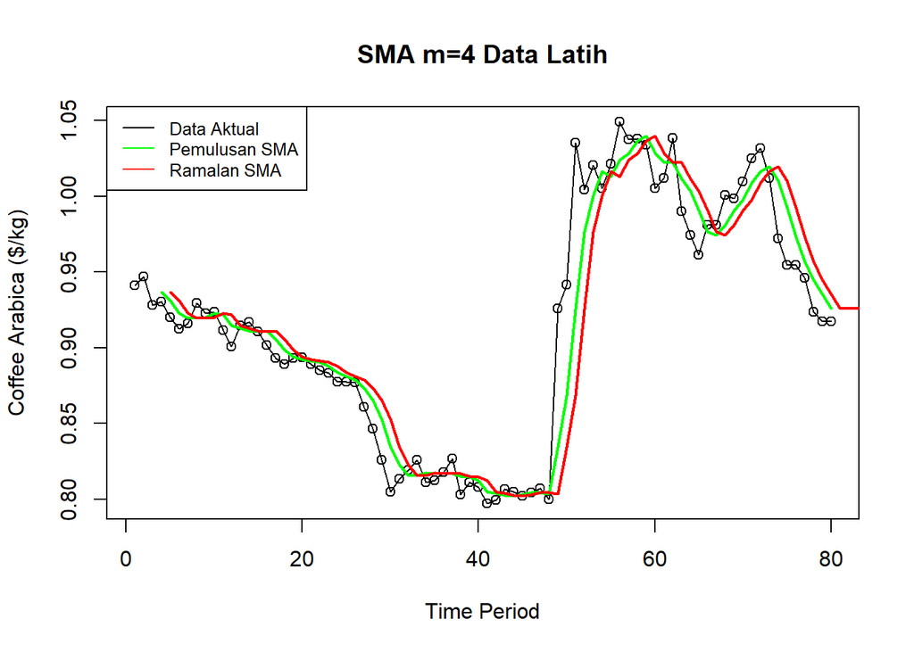

```r
# Plot data aktual, hasil pemulusan, dan ramalan
ts.plot(train_ma.ts, xlab = "Time Period", ylab = "Coffee Arabica ($/kg)",
        main = "SMA m=4 Data Latih")
points(train_ma.ts)
lines(data.gab[,2], col = "green", lwd = 2)  # garis pemulusan
lines(data.gab[,3], col = "red", lwd = 2)    # garis ramalan
legend("topleft", c("Data Aktual", "Pemulusan SMA", "Ramalan SMA"),
       lty = 1, col = c("black","green","red"), cex = 0.8)
```

```r
# Samakan panjang data.ramal dengan train_ma.ts
data.ramal_train <- data.ramal[1:length(train_ma.ts)]

# Hitung error (abaikan NA)
error_train.sma <- train_ma.ts - data.ramal_train
valid_index <- !is.na(error_train.sma)  # hanya ambil yang tidak NA

error_valid <- error_train.sma[valid_index]
aktual_valid <- train_ma.ts[valid_index]

# Hitung ukuran akurasi
SSE_train.sma <- sum(error_valid^2)
MSE_train.sma <- mean(error_valid^2)
MAPE_train.sma <- mean(abs(error_valid / aktual_valid) * 100)

# Simpan hasil ke matriks
akurasi_train.sma <- matrix(c(SSE_train.sma, MSE_train.sma, MAPE_train.sma))
row.names(akurasi_train.sma) <- c("SSE", "MSE", "MAPE")
colnames(akurasi_train.sma) <- c("Akurasi SMA m = 4")

akurasi_train.sma
```

```
##      Akurasi SMA m = 4
## SSE        0.091026803
## MSE        0.001197721
## MAPE       2.202052679
```

Dalam hal ini nilai MAPE data latih pada metode pemulusan SMA sekitar 2%, nilai ini dapat dikategorikan sebagai nilai akurasi yang sangat baik. Selanjutnya dilakukan perhitungan nilai MAPE data uji pada metode pemulusan SMA.

```r
# Panjang data latih dan data total
n_train <- length(train_ma.ts)
n_total <- length(data100.ts)

# Ambil ramalan SMA untuk data uji secara otomatis
ramal_test_sma <- data.gab[(n_train + 1):n_total, 3]  # kolom 3 = ramalan SMA

# Hitung error
error_test.sma <- test_ma.ts - ramal_test_sma

# Hitung akurasi
SSE_test.sma <- sum(error_test.sma^2)
MSE_test.sma <- mean(error_test.sma^2)
MAPE_test.sma <- mean(abs(error_test.sma / test_ma.ts) * 100)

# Simpan ke matriks
akurasi_test.sma <- matrix(c(SSE_test.sma, MSE_test.sma, MAPE_test.sma))
row.names(akurasi_test.sma) <- c("SSE", "MSE", "MAPE")
colnames(akurasi_test.sma) <- c("Akurasi SMA m = 4")
akurasi_test.sma
```

```
##      Akurasi SMA m = 4
## SSE        0.069719743
## MSE        0.003485987
## MAPE       6.364686096
```

### Double Moving Average

```r
library(TTR)

# Pastikan data.sma sudah ada
# data.sma = SMA(train_ma.ts, n = 4)

# Hitung DMA
dma <- SMA(data.sma, n = 4)
At <- 2 * data.sma - dma
Bt <- 2 / (4 - 1) * (data.sma - dma)  # m = 4

# Ramalan untuk data latih
data.dma <- At + Bt
data.ramal2 <- c(NA, data.dma)

# Panjang data uji
n_test <- length(test_ma.ts)

# Ramalan untuk data uji
t <- 1:n_test
f <- c()
for (i in t) {
  f[i] <- At[length(At)] + Bt[length(Bt)] * i
}

# Pastikan data aktual sama dengan data latih
data2.ts <- train_ma.ts

# Gabungkan semua ke tabel sesuai syntaxmu
data.gab2 <- cbind(
  aktual      = c(data2.ts),
  pemulusan1  = c(data.sma, rep(NA, n_test)),
  pemulusan2  = c(dma, rep(NA, n_test)),
  At          = c(At, rep(NA, n_test)),
  Bt          = c(Bt, rep(NA, n_test)),
  ramalan     = c(data.ramal2, f[-1])  # f[-1] agar nyambung seperti syntaxmu
)
data.gab2
```

```
##        aktual pemulusan1 pemulusan2        At            Bt   ramalan
##   [1,] 0.9409         NA         NA        NA            NA        NA
##   [2,] 0.9469         NA         NA        NA            NA        NA
##   [3,] 0.9281         NA         NA        NA            NA        NA
##   [4,] 0.9303   0.936550         NA        NA            NA        NA
##   [5,] 0.9200   0.931325         NA        NA            NA        NA
##   [6,] 0.9123   0.922675         NA        NA            NA        NA
##   [7,] 0.9160   0.919650  0.9275500 0.9117500 -5.266667e-03        NA
##   [8,] 0.9292   0.919375  0.9232563 0.9154938 -2.587500e-03 0.9064833
##   [9,] 0.9226   0.920025  0.9204313 0.9196188 -2.708333e-04 0.9129063
##  [10,] 0.9237   0.922875  0.9204813 0.9252688  1.595833e-03 0.9193479
##  [11,] 0.9116   0.921775  0.9210125 0.9225375  5.083333e-04 0.9268646
##  [12,] 0.9006   0.914625  0.9198250 0.9094250 -3.466667e-03 0.9230458
##  [13,] 0.9145   0.912600  0.9179688 0.9072313 -3.579167e-03 0.9059583
##  [14,] 0.9167   0.910850  0.9149625 0.9067375 -2.741667e-03 0.9036521
```

[output cut: 86 more lines]

```r
# Samakan panjang antara aktual dan ramalan
ramal_dma <- data.ramal2[1:length(data100.ts)]

# Hitung error, abaikan NA
error_train.dma <- data100.ts - ramal_dma

# Hilangkan NA dari error dan data aktual sebelum dihitung
valid_index <- !is.na(error_train.dma)
error_train.dma <- error_train.dma[valid_index]
aktual_valid <- data100.ts[valid_index]

# Hitung ukuran akurasi
SSE_train.dma <- sum(error_train.dma^2)
MSE_train.dma <- mean(error_train.dma^2)
MAPE_train.dma <- mean(abs(error_train.dma / aktual_valid) * 100)

# Simpan dalam matriks
akurasi_train.dma <- matrix(c(SSE_train.dma, MSE_train.dma, MAPE_train.dma))
row.names(akurasi_train.dma) <- c("SSE", "MSE", "MAPE")
colnames(akurasi_train.dma) <- c("Akurasi DMA m = 4")

akurasi_train.dma
```

```
##      Akurasi DMA m = 4
## SSE       0.0737074715
## MSE       0.0009960469
## MAPE      2.1500350513
```

## Single Exponential Smoothing (SES) dan Double Exponential Smoothing (DES)

```r
# Untuk Single/Double Exponential Smoothing
train.ts <- ts(training$`Coffee Arabica ($/kg)`)
test.ts  <- ts(testing$`Coffee Arabica ($/kg)`)
```

### Single Exponential Smoothing (SES)

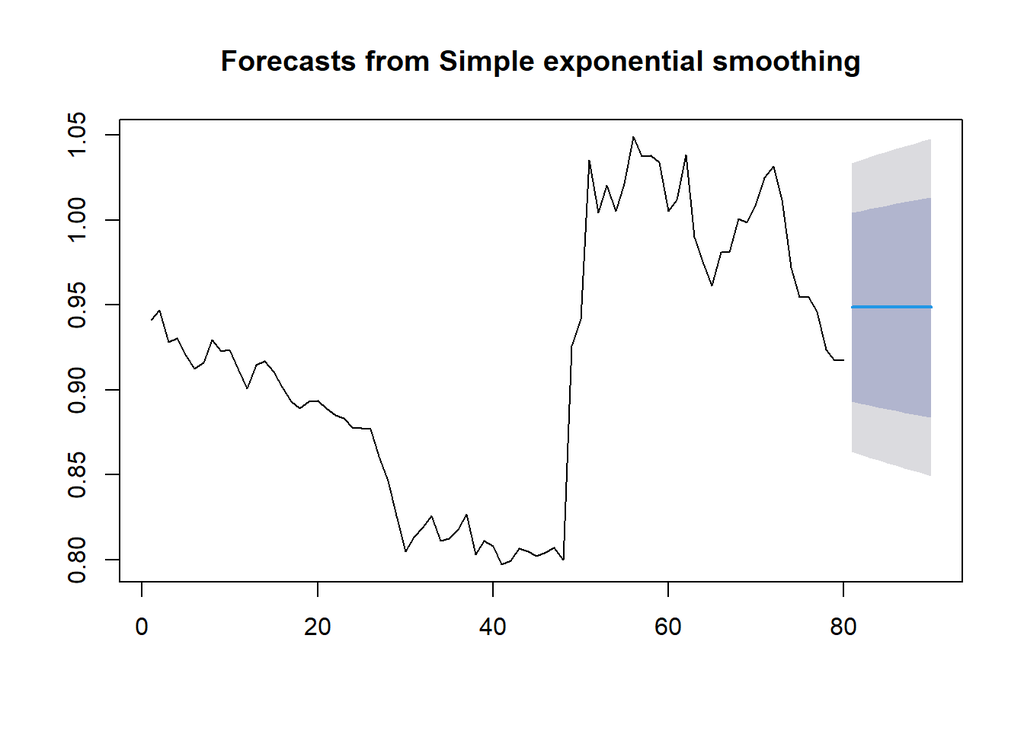

```r
#Cara 1 (fungsi ses)
ses.1 <- ses(train.ts, h = 10, alpha = 0.2)
plot(ses.1)
```

```r
ses.1
```

```
##    Point Forecast     Lo 80    Hi 80     Lo 95    Hi 95
## 81      0.9485411 0.8928698 1.004212 0.8633992 1.033683
## 82      0.9485411 0.8917673 1.005315 0.8617131 1.035369
## 83      0.9485411 0.8906858 1.006396 0.8600590 1.037023
## 84      0.9485411 0.8896241 1.007458 0.8584354 1.038647
## 85      0.9485411 0.8885813 1.008501 0.8568405 1.040242
## 86      0.9485411 0.8875563 1.009526 0.8552728 1.041809
## 87      0.9485411 0.8865482 1.010534 0.8537311 1.043351
## 88      0.9485411 0.8855562 1.011526 0.8522140 1.044868
## 89      0.9485411 0.8845797 1.012503 0.8507205 1.046362
## 90      0.9485411 0.8836178 1.013465 0.8492494 1.047833
```

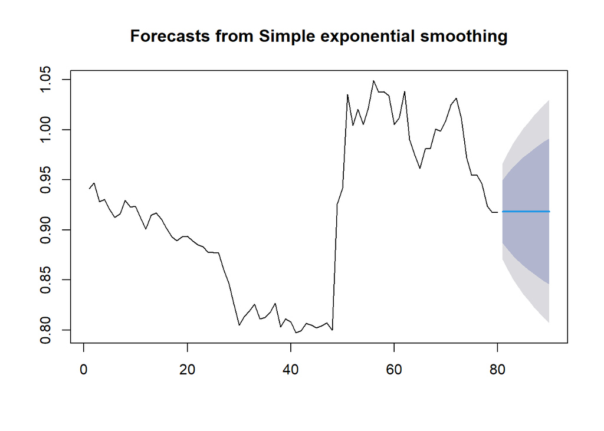

```r
ses.2<- ses(train.ts, h = 10, alpha = 0.7)
plot(ses.2)
```

```r
ses.2
```

```
##    Point Forecast     Lo 80     Hi 80     Lo 95     Hi 95
## 81      0.9183846 0.8869963 0.9497728 0.8703804 0.9663887
## 82      0.9183846 0.8800703 0.9566988 0.8597880 0.9769811
## 83      0.9183846 0.8742174 0.9625517 0.8508367 0.9859324
## 84      0.9183846 0.8690541 0.9677150 0.8429401 0.9938290
## 85      0.9183846 0.8643822 0.9723869 0.8357951 1.0009740
## 86      0.9183846 0.8600835 0.9766856 0.8292208 1.0075483
## 87      0.9183846 0.8560807 0.9806884 0.8230990 1.0136701
## 88      0.9183846 0.8523200 0.9844491 0.8173475 1.0194216
## 89      0.9183846 0.8487621 0.9880070 0.8119062 1.0248629
## 90      0.9183846 0.8453774 0.9913917 0.8067297 1.0300394
```

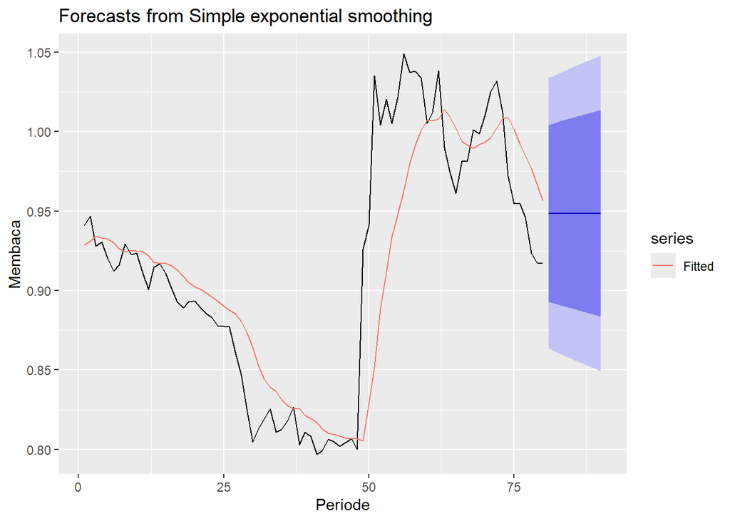

```r
autoplot(ses.1) +
  autolayer(fitted(ses.1), series="Fitted") +
  ylab("Membaca") + xlab("Periode")
```

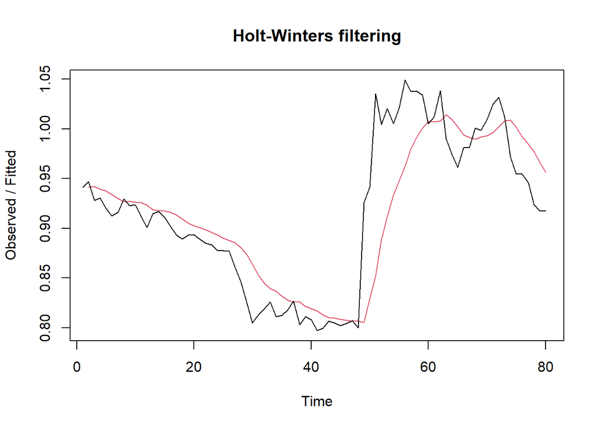

```r
#Cara 2 (fungsi Holtwinter)
ses1<- HoltWinters(train.ts, gamma = FALSE, beta = FALSE, alpha = 0.2)
plot(ses1)
```

```r
#ramalan
ramalan1<- forecast(ses1, h=10)
ramalan1
```

```
##    Point Forecast     Lo 80    Hi 80     Lo 95    Hi 95
## 81      0.9485411 0.8927932 1.004289 0.8632820 1.033800
## 82      0.9485411 0.8916892 1.005393 0.8615936 1.035489
## 83      0.9485411 0.8906062 1.006476 0.8599373 1.037145
## 84      0.9485411 0.8895431 1.007539 0.8583114 1.038771
## 85      0.9485411 0.8884988 1.008584 0.8567143 1.040368
## 86      0.9485411 0.8874723 1.009610 0.8551445 1.041938
## 87      0.9485411 0.8864629 1.010619 0.8536006 1.043482
## 88      0.9485411 0.8854695 1.011613 0.8520815 1.045001
## 89      0.9485411 0.8844916 1.012591 0.8505859 1.046496
## 90      0.9485411 0.8835284 1.013554 0.8491128 1.047970
```

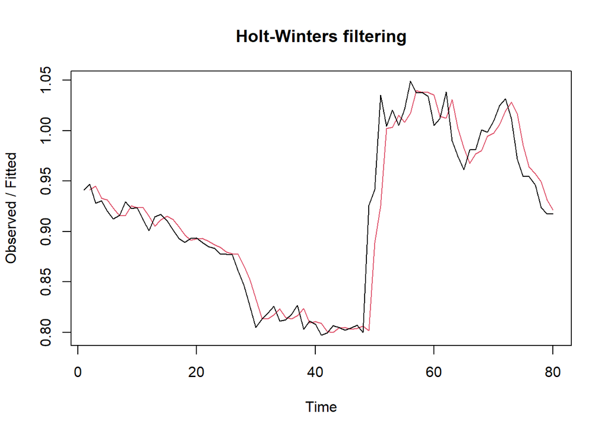

```r
ses2<- HoltWinters(train.ts, gamma = FALSE, beta = FALSE, alpha = 0.7)
plot(ses2)
```

```r
#ramalan
ramalan2<- forecast(ses2, h=10)
ramalan2
```

```
##    Point Forecast     Lo 80     Hi 80     Lo 95     Hi 95
## 81      0.9183846 0.8870007 0.9497684 0.8703871 0.9663820
## 82      0.9183846 0.8800757 0.9566934 0.8597962 0.9769729
## 83      0.9183846 0.8742236 0.9625455 0.8508462 0.9859229
## 84      0.9183846 0.8690610 0.9677081 0.8429507 0.9938185
## 85      0.9183846 0.8643898 0.9723794 0.8358066 1.0009625
## 86      0.9183846 0.8600917 0.9766775 0.8292333 1.0075358
## 87      0.9183846 0.8560894 0.9806797 0.8231123 1.0136568
## 88      0.9183846 0.8523292 0.9844399 0.8173616 1.0194075
## 89      0.9183846 0.8487718 0.9879973 0.8119211 1.0248480
## 90      0.9183846 0.8453876 0.9913815 0.8067453 1.0300238
```

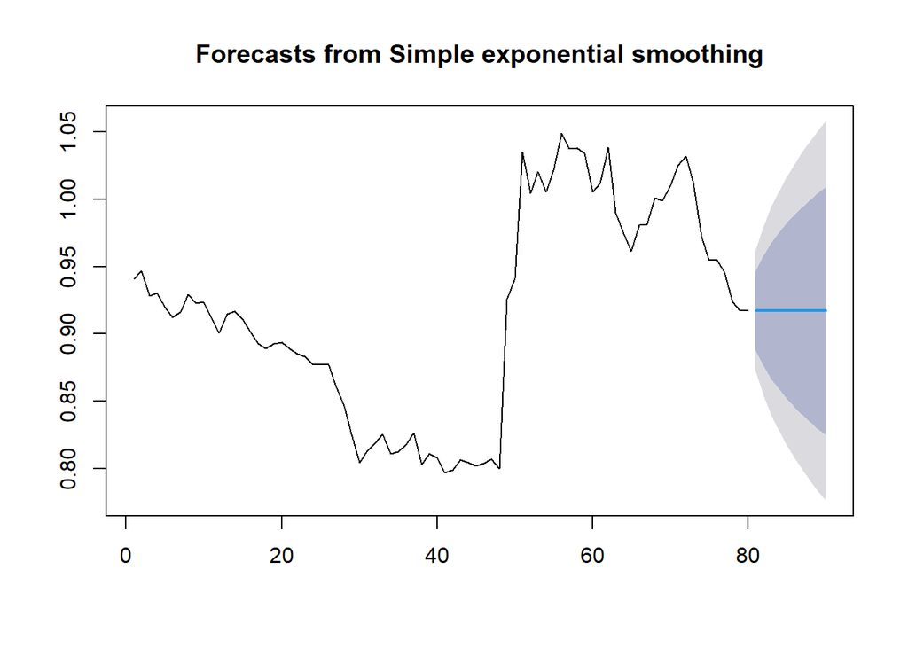

```r
#SES
ses.opt <- ses(train.ts, h = 10, alpha = NULL)
plot(ses.opt)
```

```r
ses.opt
```

```
##    Point Forecast     Lo 80     Hi 80     Lo 95     Hi 95
## 81         0.9171 0.8880055 0.9461945 0.8726039 0.9615961
## 82         0.9171 0.8759563 0.9582437 0.8541761 0.9800239
## 83         0.9171 0.8667103 0.9674897 0.8400356 0.9941644
## 84         0.9171 0.8589155 0.9752845 0.8281144 1.0060856
## 85         0.9171 0.8520481 0.9821519 0.8176116 1.0165884
## 86         0.9171 0.8458394 0.9883606 0.8081163 1.0260837
## 87         0.9171 0.8401299 0.9940701 0.7993844 1.0348156
## 88         0.9171 0.8348157 0.9993843 0.7912570 1.0429430
## 89         0.9171 0.8298244 1.0043756 0.7836235 1.0505765
## 90         0.9171 0.8251036 1.0090964 0.7764036 1.0577964
```

```r
#Lamda Optimum Holt Winter
HWopt<- HoltWinters(train.ts, gamma = FALSE, beta = FALSE,alpha = NULL)
HWopt
```

```
## Holt-Winters exponential smoothing without trend and without seasonal component.
##
## Call:
## HoltWinters(x = train.ts, alpha = NULL, beta = FALSE, gamma = FALSE)
##
## Smoothing parameters:
##  alpha: 0.9999207
##  beta : FALSE
##  gamma: FALSE
##
## Coefficients:
##     [,1]
## a 0.9171
```

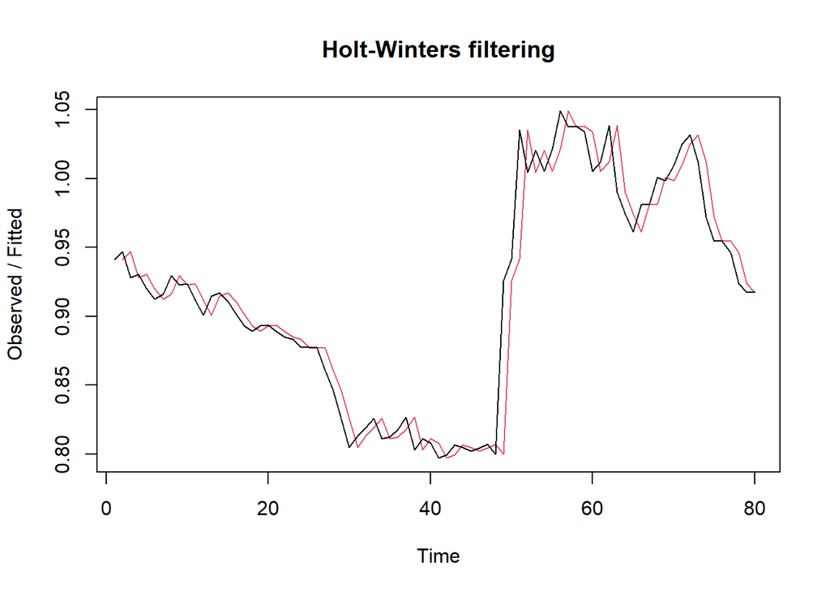

```r
plot(HWopt)
```

```r
#ramalan
ramalanopt<- forecast(HWopt, h=10)
ramalanopt
```

```
##    Point Forecast     Lo 80     Hi 80     Lo 95     Hi 95
## 81         0.9171 0.8880082 0.9461918 0.8726079 0.9615921
## 82         0.9171 0.8759595 0.9582405 0.8541811 0.9800189
## 83         0.9171 0.8667141 0.9674859 0.8400414 0.9941586
## 84         0.9171 0.8589198 0.9752802 0.8281210 1.0060790
## 85         0.9171 0.8520528 0.9821472 0.8176189 1.0165811
## 86         0.9171 0.8458445 0.9883555 0.8081242 1.0260758
## 87         0.9171 0.8401354 0.9940646 0.7993929 1.0348071
## 88         0.9171 0.8348215 0.9993785 0.7912659 1.0429341
## 89         0.9171 0.8298306 1.0043694 0.7836330 1.0505670
## 90         0.9171 0.8251101 1.0090899 0.7764135 1.0577865
```

#### Akurasi Data Latih

```r
#Keakuratan Metode
#Pada data training

# SES dengan alpha = 0.2
SSE1<-ses1$SSE
MSE1<-ses1$SSE/length(train.ts)
RMSE1<-sqrt(MSE1)

akurasi1 <- matrix(c(SSE1,MSE1,RMSE1))
row.names(akurasi1)<- c("SSE", "MSE", "RMSE")
colnames(akurasi1) <- c("Akurasi lamda=0.2")
akurasi1
```

```
##      Akurasi lamda=0.2
## SSE        0.147616349
## MSE        0.001845204
## RMSE       0.042955842
```

```r
# SES dengan alpha = 0.7
SSE2<-ses2$SSE
MSE2<-ses2$SSE/length(train.ts)
RMSE2<-sqrt(MSE2)

akurasi2 <- matrix(c(SSE2,MSE2,RMSE2))
row.names(akurasi2)<- c("SSE", "MSE", "RMSE")
colnames(akurasi2) <- c("Akurasi lamda=0.7")
akurasi2
```

```
##      Akurasi lamda=0.7
## SSE       0.0467903404
## MSE       0.0005848793
## RMSE      0.0241842770
```

```r
#Cara Manual
# Alpha = 0.2
fitted1<-ramalan1$fitted
sisaan1<-ramalan1$residuals
head(sisaan1)
```

```
## Time Series:
## Start = 1
## End = 6
## Frequency = 1
## [1]      NA  0.0060 -0.0140 -0.0090 -0.0175 -0.0217
```

```r
resid1<-training$'Coffee Arabica ($/kg)'-ramalan1$fitted
head(resid1)
```

```
## Time Series:
## Start = 1
## End = 6
## Frequency = 1
## [1]      NA  0.0060 -0.0140 -0.0090 -0.0175 -0.0217
```

```r
SSE.1=sum(sisaan1[2:length(train.ts)]^2)
SSE.1
```

```
## [1] 0.1476163
```

```r
MSE.1 = SSE.1/length(train.ts)
MSE.1
```

```
## [1] 0.001845204
```

```r
MAPE.1 = sum(abs(sisaan1[2:length(train.ts)]/train.ts[2:length(train.ts)])*
               100)/length(train.ts)
MAPE.1
```

```
## [1] 3.007678
```

```r
akurasi.1 <- matrix(c(SSE.1,MSE.1,MAPE.1))
row.names(akurasi.1)<- c("SSE", "MSE", "MAPE")
colnames(akurasi.1) <- c("Akurasi lamda=0.2")
akurasi.1
```

```
##      Akurasi lamda=0.2
## SSE        0.147616349
## MSE        0.001845204
## MAPE       3.007677864
```

```r
# Alpha = 0.7
fitted2<-ramalan2$fitted
sisaan2<-ramalan2$residuals
head(sisaan2)
```

```
## Time Series:
## Start = 1
## End = 6
## Frequency = 1
## [1]        NA  0.006000 -0.017000 -0.002900 -0.011170 -0.011051
```

```r
resid2<-training$'Coffee Arabica ($/kg)'-ramalan2$fitted
head(resid2)
```

```
## Time Series:
## Start = 1
## End = 6
## Frequency = 1
## [1]        NA  0.006000 -0.017000 -0.002900 -0.011170 -0.011051
```

```r
SSE.2=sum(sisaan2[2:length(train.ts)]^2)
SSE.2
```

```
## [1] 0.04679034
```

```r
MSE.2 = SSE.2/length(train.ts)
MSE.2
```

```
## [1] 0.0005848793
```

```r
MAPE.2 = sum(abs(sisaan2[2:length(train.ts)]/train.ts[2:length(train.ts)])*
               100)/length(train.ts)
MAPE.2
```

```
## [1] 1.487515
```

```r
akurasi.2 <- matrix(c(SSE.2,MSE.2,MAPE.2))
row.names(akurasi.2)<- c("SSE", "MSE", "MAPE")
colnames(akurasi.2) <- c("Akurasi lamda=0.7")
akurasi.2
```

```
##      Akurasi lamda=0.7
## SSE       0.0467903404
## MSE       0.0005848793
## MAPE      1.4875150379
```

Berdasarkan hasil evaluasi model, dapat dilihat bahwa **parameter λ = 0,7 menghasilkan akurasi yang lebih baik dibandingkan λ = 0,2**. Hal ini ditunjukkan oleh nilai SSE, MSE, dan RMSE yang lebih kecil pada λ = 0,7. Dengan demikian, λ = 0,7 lebih optimal digunakan dalam pemodelan karena mampu meminimalkan kesalahan peramalan.

#### Akurasi Data

```r
# jumlah observasi uji
n_test <- nrow(testing)

# error (ramalan - aktual), samakan panjang dan tipe numeric
e1   <- as.numeric(ramalan1$mean)[1:n_test] - as.numeric(testing$'Coffee Arabica ($/kg)')
e2   <- as.numeric(ramalan2$mean)[1:n_test] - as.numeric(testing$'Coffee Arabica ($/kg)')
eopt <- as.numeric(ramalanopt$mean)[1:n_test] - as.numeric(testing$'Coffee Arabica ($/kg)')

# SSE / MSE / RMSE untuk masing-masing model (abaikan NA)
SSEtesting1  <- sum(e1^2,  na.rm = TRUE)
MSEtesting1  <- mean(e1^2, na.rm = TRUE)
RMSEtesting1 <- sqrt(MSEtesting1)

SSEtesting2  <- sum(e2^2,  na.rm = TRUE)
MSEtesting2  <- mean(e2^2, na.rm = TRUE)
RMSEtesting2 <- sqrt(MSEtesting2)

SSEtestingopt  <- sum(eopt^2,  na.rm = TRUE)
MSEtestingopt  <- mean(eopt^2, na.rm = TRUE)
RMSEtestingopt <- sqrt(MSEtestingopt)

# Tabel ringkas
akurasitesting_SSE <- matrix(c(SSEtesting1, SSEtesting2, SSEtestingopt),
                             nrow = 3,
                             dimnames = list(c("SSE1","SSE2","SSEopt"), "Nilai"))
akurasitesting_MSE <- matrix(c(MSEtesting1, MSEtesting2, MSEtestingopt),
                             nrow = 3,
                             dimnames = list(c("MSE1","MSE2","MSEopt"), "Nilai"))
akurasitesting_RMSE <- matrix(c(RMSEtesting1, RMSEtesting2, RMSEtestingopt),
                              nrow = 3,
                              dimnames = list(c("RMSE1","RMSE2","RMSEopt"), "Nilai"))

akurasitesting_SSE
```

```
##             Nilai
## SSE1   0.06659008
## SSE2   0.02914594
## SSEopt 0.02795484
```

```r
akurasitesting_MSE
```

```
##              Nilai
## MSE1   0.006659008
## MSE2   0.002914594
## MSEopt 0.002795484
```

```r
akurasitesting_RMSE
```

```
##              Nilai
## RMSE1   0.08160274
## RMSE2   0.05398698
## RMSEopt 0.05287234
```

### Double Exponential Smoothing

#### Pembagian Data

Pembagian data latih dan data uji dilakukan dengan perbandingan 80% data latih dan 20% data uji.

```r
# jumlah baris data
n <- nrow(data100)

# hitung batas 80%
n_train <- floor(0.8 * n)

# bagi data
training <- data100[1:n_train, ]
testing  <- data100[(n_train+1):n, ]

# ubah ke time series
train.ts <- ts(training$`Coffee Arabica ($/kg)`)
test.ts  <- ts(testing$`Coffee Arabica ($/kg)`)
```

#### Eksplorasi

Eksplorasi dilakukan dengan membuat plot data deret waktu untuk keseluruhan data, data latih, dan data uji.

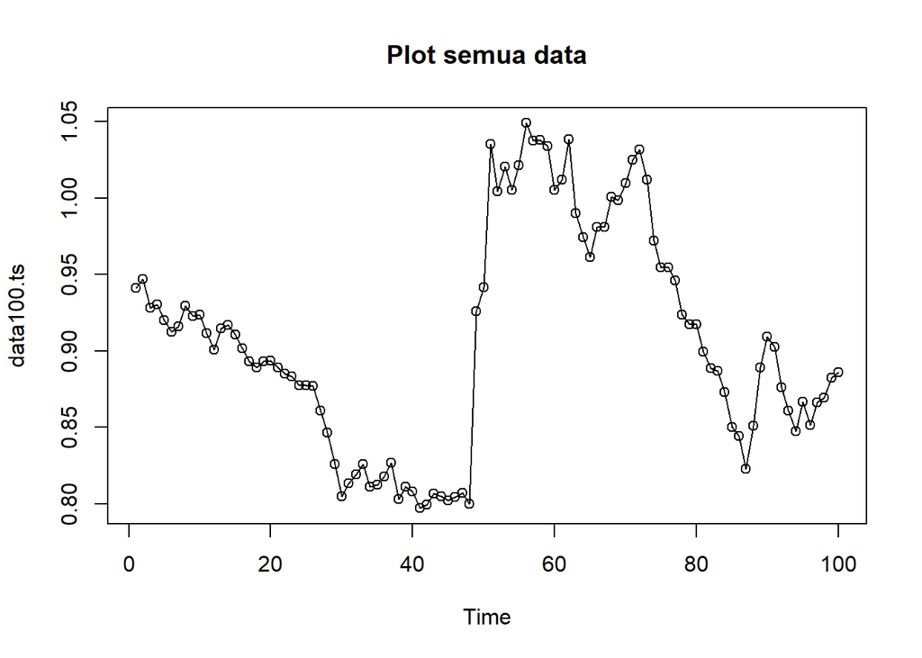

```r
#eksplorasi data
plot(data100.ts, col="black",main="Plot semua data")
points(data100.ts)
```

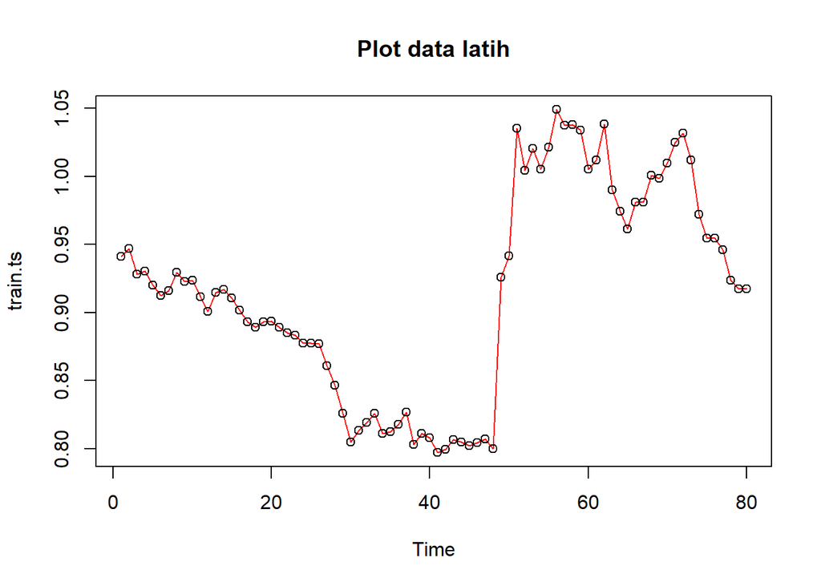

```r
plot(train.ts, col="red",main="Plot data latih")
points(train.ts)
```

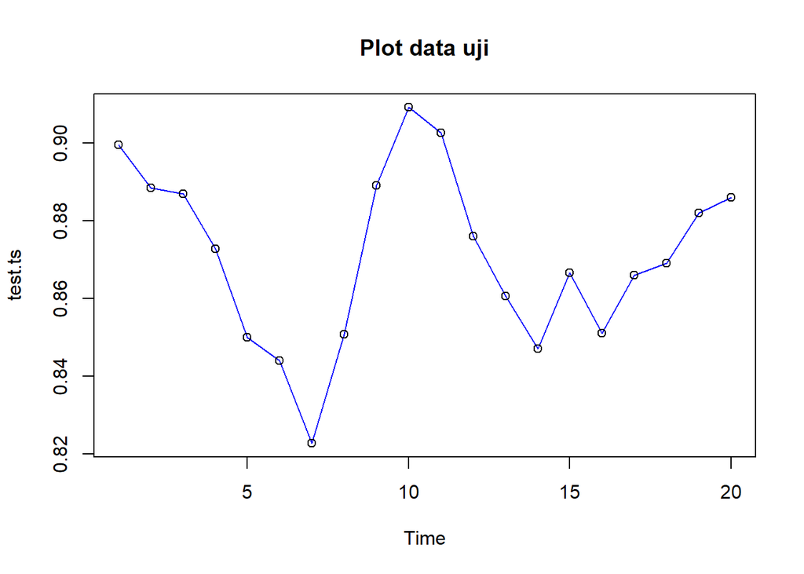

```r
plot(test.ts, col="blue",main="Plot data uji")
points(test.ts)
```

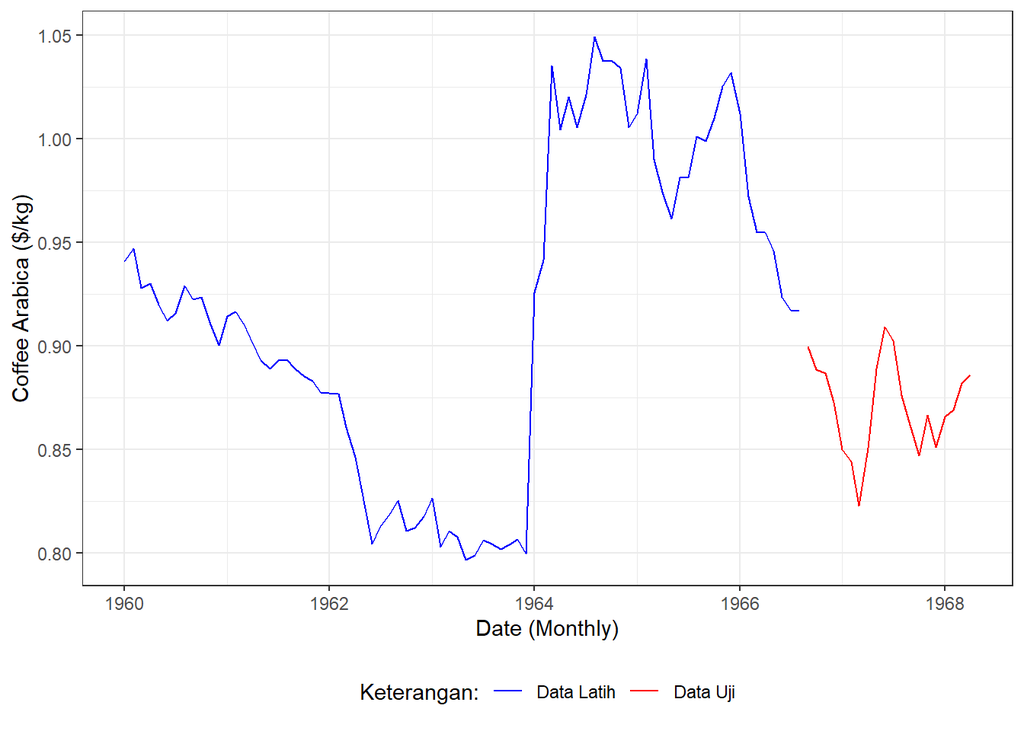

```r
ggplot() +
  geom_line(data = training, aes(x = `Date (Monthly)`, y = `Coffee Arabica ($/kg)`, col = "Data Latih")) +
  geom_line(data = testing, aes(x = `Date (Monthly)`, y = `Coffee Arabica ($/kg)`, col = "Data Uji")) +
  labs(x = "Date (Monthly)", y = "Coffee Arabica ($/kg)", color = "Legend") +
  scale_colour_manual(name = "Keterangan:", breaks = c("Data Latih", "Data Uji"),
                      values = c("blue", "red")) +
  theme_bw() +
  theme(legend.position = "bottom",
        plot.caption = element_text(hjust = 0.5, size = 12))
```

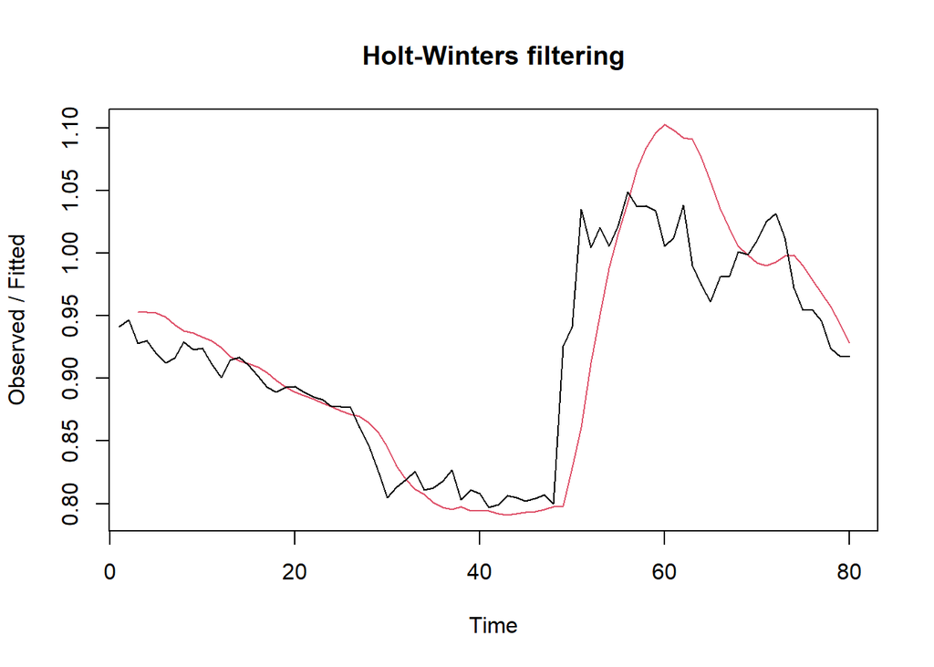

```r
#Lamda=0.2 dan gamma=0.2
des.1<- HoltWinters(train.ts, gamma = FALSE, beta = 0.2, alpha = 0.2)
plot(des.1)
```

```r
#ramalan
ramalandes1<- forecast(des.1, h=10)
ramalandes1
```

```
##    Point Forecast     Lo 80     Hi 80     Lo 95     Hi 95
## 81      0.9170801 0.8600630 0.9740971 0.8298800 1.0042801
## 82      0.9078087 0.8491726 0.9664449 0.8181325 0.9974850
## 83      0.8985374 0.8377668 0.9593081 0.8055967 0.9914781
## 84      0.8892661 0.8258156 0.9527166 0.7922269 0.9863053
## 85      0.8799948 0.8133068 0.9466828 0.7780043 0.9819853
## 86      0.8707235 0.8002434 0.9412036 0.7629335 0.9785135
## 87      0.8614522 0.7866402 0.9362641 0.7470372 0.9758671
## 88      0.8521808 0.7725200 0.9318416 0.7303502 0.9740115
## 89      0.8429095 0.7579101 0.9279089 0.7129142 0.9729049
## 90      0.8336382 0.7428396 0.9244368 0.6947737 0.9725027
```

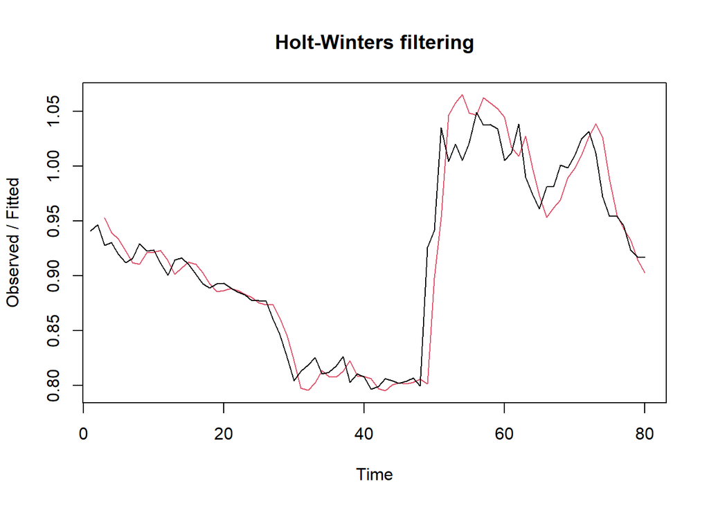

```r
#Lamda=0.6 dan gamma=0.3
des.2<- HoltWinters(train.ts, gamma = FALSE, beta = 0.3, alpha = 0.6)
plot(des.2)
```

```r
#ramalan
ramalandes2<- forecast(des.2, h=10)
ramalandes2
```

```
##    Point Forecast     Lo 80     Hi 80     Lo 95     Hi 95
## 81      0.9012217 0.8683675 0.9340758 0.8509756 0.9514677
## 82      0.8909437 0.8492771 0.9326102 0.8272202 0.9546671
## 83      0.8806656 0.8284079 0.9329233 0.8007444 0.9605869
## 84      0.8703876 0.8060942 0.9346811 0.7720593 0.9687160
## 85      0.8601096 0.7825571 0.9376621 0.7415033 0.9787159
## 86      0.8498316 0.7579457 0.9417175 0.7093042 0.9903590
## 87      0.8395536 0.7323644 0.9467427 0.6756220 1.0034852
## 88      0.8292755 0.7058909 0.9526602 0.6405750 1.0179761
## 89      0.8189975 0.6785846 0.9594104 0.6042545 1.0337405
## 90      0.8087195 0.6504935 0.9669455 0.5667337 1.0507053
```

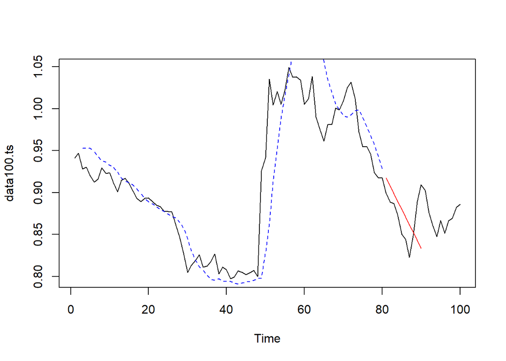

```r
plot(data100.ts)
lines(des.1$fitted[,1], lty=2, col="blue")
lines(ramalandes1$mean, col="red")
```

```r
#Lamda dan gamma optimum
des.opt<- HoltWinters(train.ts, gamma = FALSE)
des.opt
```

```
## Holt-Winters exponential smoothing with trend and without seasonal component.
##
## Call:
## HoltWinters(x = train.ts, gamma = FALSE)
##
## Smoothing parameters:
##  alpha: 0.9757875
##  beta : 0.09518793
##  gamma: FALSE
##
## Coefficients:
##           [,1]
## a  0.916968825
## b -0.004956945
```

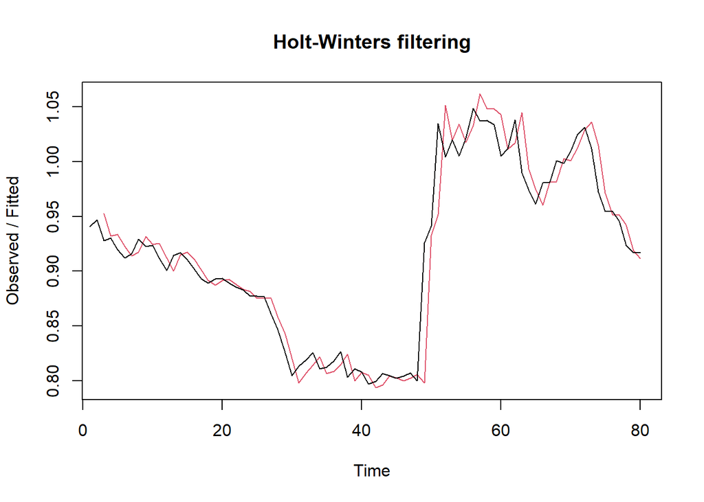

```r
plot(des.opt)
```

```r
#ramalan
ramalandesopt<- forecast(des.opt, h=10)
ramalandesopt
```

```
##    Point Forecast     Lo 80     Hi 80     Lo 95     Hi 95
## 81      0.9120119 0.8822059 0.9418179 0.8664275 0.9575962
## 82      0.9070549 0.8634316 0.9506783 0.8403387 0.9737711
## 83      0.9020980 0.8464057 0.9577903 0.8169240 0.9872720
## 84      0.8971410 0.8300618 0.9642203 0.7945522 0.9997299
## 85      0.8921841 0.8140028 0.9703654 0.7726162 1.0117520
## 86      0.8872272 0.7980363 0.9764180 0.7508215 1.0236328
## 87      0.8822702 0.7820551 0.9824853 0.7290045 1.0355359
## 88      0.8773133 0.7659949 0.9886317 0.7070665 1.0475601
## 89      0.8723563 0.7498144 0.9948982 0.6849446 1.0597680
## 90      0.8673994 0.7334868 1.0013120 0.6625977 1.0722010
```

#### Akurasi Data Latih

```r
#Akurasi Data Training
ssedes.train1<-des.1$SSE
msedes.train1<-ssedes.train1/length(train.ts)
sisaandes1<-ramalandes1$residuals
head(sisaandes1)
```

```
## Time Series:
## Start = 1
## End = 6
## Frequency = 1
## [1]          NA          NA -0.02480000 -0.02264800 -0.03252048 -0.03651764
```

```r
mapedes.train1 <- sum(abs(sisaandes1[3:length(train.ts)]/train.ts[3:length(train.ts)])
                      *100)/length(train.ts)

akurasides.1 <- matrix(c(ssedes.train1,msedes.train1,mapedes.train1))
row.names(akurasides.1)<- c("SSE", "MSE", "MAPE")
colnames(akurasides.1) <- c("Akurasi lamda=0.2 dan gamma=0.2")
akurasides.1
```

```
##      Akurasi lamda=0.2 dan gamma=0.2
## SSE                      0.154283803
## MSE                      0.001928548
## MAPE                     2.942870868
```

```r
ssedes.train2<-des.2$SSE
msedes.train2<-ssedes.train2/length(train.ts)
sisaandes2<-ramalandes2$residuals
head(sisaandes2)
```

```
## Time Series:
## Start = 1
## End = 6
## Frequency = 1
## [1]          NA          NA -0.02480000 -0.00925600 -0.01387232 -0.01062183
```

```r
mapedes.train2 <- sum(abs(sisaandes2[3:length(train.ts)]/train.ts[3:length(train.ts)])
                      *100)/length(train.ts)

akurasides.2 <- matrix(c(ssedes.train2,msedes.train2,mapedes.train2))
row.names(akurasides.2)<- c("SSE", "MSE", "MAPE")
colnames(akurasides.2) <- c("Akurasi lamda=0.6 dan gamma=0.3")
akurasides.2
```

```
##      Akurasi lamda=0.6 dan gamma=0.3
## SSE                     0.0507104685
## MSE                     0.0006338809
## MAPE                    1.7124943120
```

Berdasarkan hasil evaluasi model pemulusan eksponensial ganda (DES), diperoleh bahwa skenario pertama dengan parameter α=0,2 dan β=0,2 menghasilkan nilai SSE sebesar 0,1543, MSE sebesar 0,00193, dan MAPE sebesar 2,94%, sedangkan skenario kedua dengan parameter α=0,6 dan β=0,3 memberikan hasil yang lebih baik dengan nilai SSE sebesar 0,0507, MSE sebesar 0,00063, dan MAPE sebesar 1,71%. Kedua skenario termasuk dalam kategori peramalan sangat baik karena MAPE < 10%, namun skenario kedua dapat dikatakan lebih optimal karena memiliki nilai error yang lebih rendah dibandingkan skenario pertama.

```r
selisihdes1 <- as.numeric(ramalandes1$mean) - testing$`Coffee Arabica ($/kg)`
selisihdes1
```

```
##  [1]  0.017580057  0.019308740  0.011637422  0.016466105  0.029894788
##  [6]  0.026623470  0.038652153  0.001380836 -0.046190482 -0.075561799
## [11]  0.014480057  0.031708740  0.037837422  0.042066105  0.013394788
## [16]  0.019523470 -0.004547847 -0.016919164 -0.039190482 -0.052361799
```

```r
SSEtestingdes1 <- sum(selisihdes1^2)
MSEtestingdes1 <- SSEtestingdes1 / length(testing$`Coffee Arabica ($/kg)`)
MAPEtestingdes1 <- mean(abs(selisihdes1 / testing$`Coffee Arabica ($/kg)`)) * 100

selisihdes2 <- as.numeric(ramalandes2$mean) - testing$`Coffee Arabica ($/kg)`
selisihdes2
```

```
##  [1]  0.001721671  0.002443652 -0.006234366 -0.002412385  0.010009596
##  [6]  0.005731577  0.016753559 -0.021524460 -0.070102479 -0.100480498
## [11] -0.001378329  0.014843652  0.019965634  0.023187615 -0.006490404
## [16] -0.001368423 -0.026446441 -0.039824460 -0.063102479 -0.077280498
```

```r
SSEtestingdes2 <- sum(selisihdes2^2)
MSEtestingdes2 <- SSEtestingdes2 / length(testing$`Coffee Arabica ($/kg)`)
MAPEtestingdes2 <- mean(abs(selisihdes2 / testing$`Coffee Arabica ($/kg)`)) * 100

selisihdesopt <- as.numeric(ramalandesopt$mean) - testing$`Coffee Arabica ($/kg)`
selisihdesopt
```

```
##  [1]  0.012511880  0.018554935  0.015197989  0.024341044  0.042084099
##  [6]  0.043127154  0.059470209  0.026513264 -0.016743681 -0.041800626
## [11]  0.009411880  0.030954935  0.041397989  0.049941044  0.025584099
## [16]  0.036027154  0.016270209  0.008213264 -0.009743681 -0.018600626
```

```r
SSEtestingdesopt <- sum(selisihdesopt^2)
MSEtestingdesopt <- SSEtestingdesopt / length(testing$`Coffee Arabica ($/kg)`)
MAPEtestingdesopt <- mean(abs(selisihdesopt / testing$`Coffee Arabica ($/kg)`)) * 100

akurasitestingdes <- matrix(
  c(SSEtestingdes1, MSEtestingdes1, MAPEtestingdes1,
    SSEtestingdes2, MSEtestingdes2, MAPEtestingdes2,
    SSEtestingdesopt, MSEtestingdesopt, MAPEtestingdesopt),
  nrow = 3, ncol = 3,
  dimnames = list(c("SSE", "MSE", "MAPE"),
                  c("DES Skenario 1", "DES Skenario 2", "DES Optimum"))
)

akurasitestingdes
```

```
##      DES Skenario 1 DES Skenario 2  DES Optimum
## SSE     0.021591520    0.029383461 0.0192029179
## MSE     0.001079576    0.001469173 0.0009601459
## MAPE    3.180596955    2.906503751 3.1679759004
```

### Perbandingan SES dan DES

```r
MSEfull <-
  matrix(c(MSEtesting1,MSEtesting2,MSEtestingopt,MSEtestingdes1,MSEtestingdes2,
           MSEtestingdesopt),nrow=3,ncol=2)
row.names(MSEfull)<- c("ske 1", "ske 2", "ske opt")
colnames(MSEfull) <- c("ses","des")
MSEfull
```

```
##                 ses          des
## ske 1   0.006659008 0.0010795760
## ske 2   0.002914594 0.0014691731
## ske opt 0.002795484 0.0009601459
```

Berdasarkan nilai **MSE** pada tabel perbandingan, terlihat bahwa untuk **skenario 1, skenario 2, maupun skenario optimum**, metode **Double Exponential Smoothing (DES)** selalu memberikan nilai MSE yang lebih kecil dibandingkan dengan metode **Single Exponential Smoothing (SES)**. Hal ini menunjukkan bahwa **DES lebih baik daripada SES** dalam menghasilkan peramalan pada data harga kopi Arabica, karena mampu meminimalkan kesalahan ramalan. Dengan kata lain, **DES (khususnya pada parameter optimum)** adalah metode yang paling akurat dan lebih direkomendasikan untuk digunakan dibandingkan SES.

# Kesimpulan